# (Ford GoBike System Data Exploration )

## by (Samaa Elhares )

## Preliminary Wrangling

> This data set includes information about individual rides made in a bike-sharing system covering the greater San Francisco Bay area

## What are the most days for a bike ride?

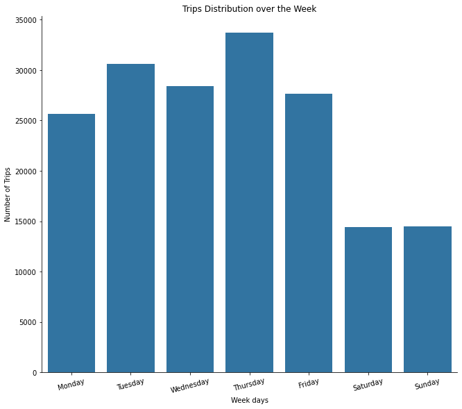

> **Obs1:** It seems that days from Monday : Friday is the most frequent days for bikes trips but Thursdays are the most frquent,  
> Saturdays and Sundays aren't very popular as the rest.

> **Obs2:** The most usage is during 7:9 am and 4:7 pm

## During Which month do trips take place ?

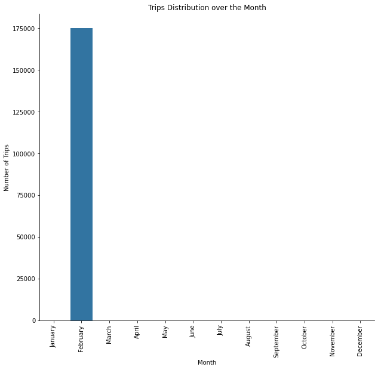

> **Obs3:** Apperently There are no trips over the year but in February.

### The age range

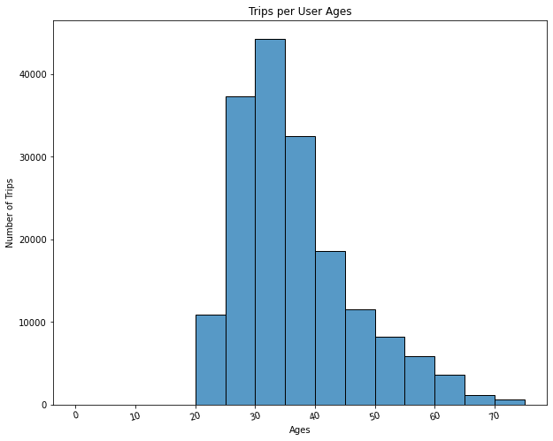

> **Obs4:** The distribution is skewed to the right which is normal, that ages from 25 to 45 are the most demanding population. and the mean of age is nearly 35.

## Trip Duration

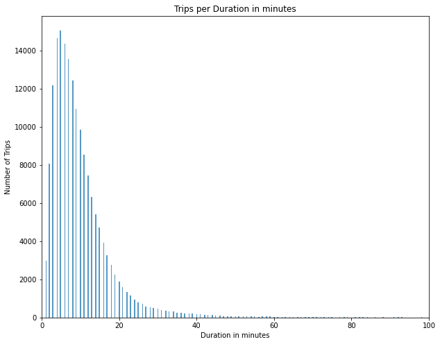

> **Obs5:** More than 95% of the trips takes 25 minutes maximum

## Who rented bikes more during the week, Customers or Subscribers?

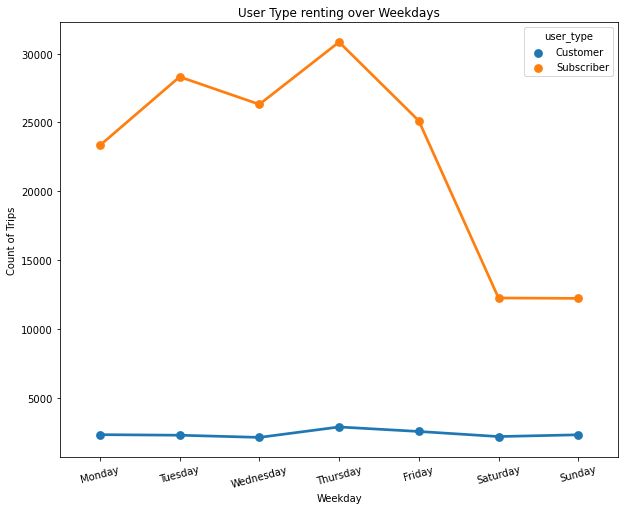

> **Obs11:** Subscribers are killin it over all days  
> noticing the decrease duting weekend days they are propably using it to go to work.

## consumption on a daily usage

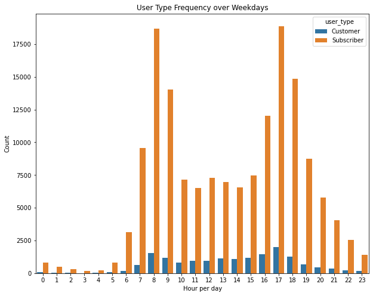

> **Obs12:** Subscribers uses during the morning to go to work and by the late afternoon.

## Age distribution between User Types

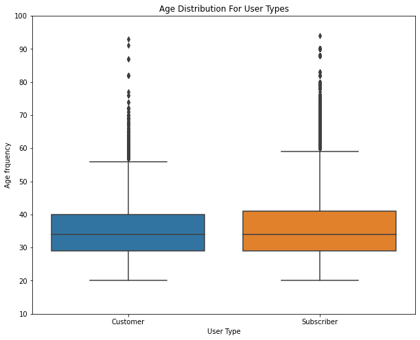

> **Obs14:** Subscribers have wider range of ages, but customers have slightly younger users.

## What the average trip duration through weekdays for Subscribers and Customers?

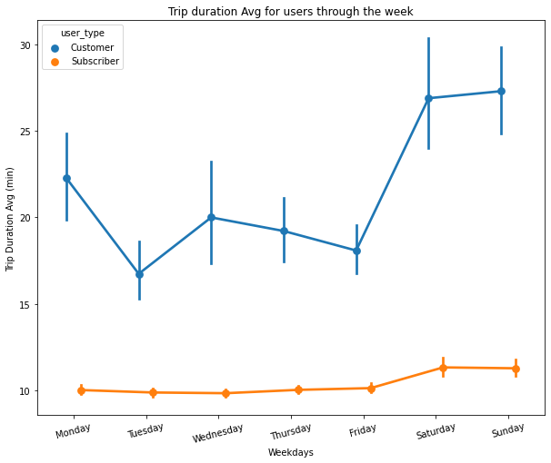

> **Obs15:** Subscribers ride shorter compared to customers during the weekdays.

## What the average trip duration through Day-hours for Subscribers and Customers?

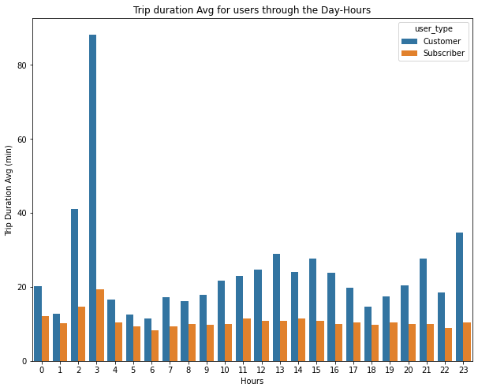